# HW 4: Unabomber Report

# Import cleaned version into Quanteda

Now that I’ve cleaned the text, I need to amend this output to be compatible with Quanteda’s `corpus` function, which expects a continous text as input, not a dataframe like what I have above. I’m going to reconstruct the text in the proper word order using the `unabomb_tokendf` with only the “clean” words, and then look at it using Quanteda.

```r
# First, reconstruct cleaned text from unabomb_clean df
unabomb_text <- paste(na.omit(unabomb_tokendf$word_clean), collapse = " ") # Don't include any NA values from the df and add spaces between the words
unabomb_text
```

```
## [1] "industrial society future introduction industrial revolution consequence have disaster human race have greatly increase life expectancy live advance country have destabilize society have make life unfulfilling have subject human being indignity have lead widespread psychological suffer world…
```

```r
# Next, put into Quanteda corpus
unabomb_corpus <- corpus(unabomb_text)
summary(unabomb_corpus)
```

```
## Corpus consisting of 1 document, showing 1 document:
##
##   Text Types Tokens Sentences
##  text1  2946  19255         1
```

By removing the stop words and lemmatizing words, the manifesto looks pretty different. Now `unabomb_corpus` is the Quanteda corpus, consisting of a single text, with 2946 types (unique words) and 19255 tokens (total words, albeit cleaned).

Let’s look at how the document changed by comparing pre- to post-cleaning corpora.

# Table of lexical characteristics pre- and post-cleaning

Now, let’s look at TTR (type-token ratio for proportion of unique words) and some other stats to see lexical diversity and distributions.

```r
library(quanteda.textstats)
# First, make a corpus of the original text and look at it
pre_corp <- corpus(unabomb) # Making a corpus of the original imported document
# summary(pre_corp)
# Output shows 3321 documents (AKA lines of text in this case), and the number of types, tokens, and "sentences"
# (e.g., blank lines are 0 sentences; words of any kind are 1 sentence, and for each punctuation mark in a line,
# another "sentence" is tacked on with Quanteda)

# This needs to be changed to collapse all of the documents into a single text, otherwise the tables of the pre- and post-cleaning
# texts will be very difficult to compare... 3000+ rows compared to 1 row.

# Collapse all "documents" into a single one
pre_corp <- corpus(paste(unabomb, collapse = " ")) # Join every element (line) of unabomb vector into a single string with a space between each
summary(pre_corp)
```

```
## Corpus consisting of 1 document, showing 1 document:
##
##   Text Types Tokens Sentences
##  text1  4849  38997      1792
```

```r
summary(unabomb_corpus)
```

```
## Corpus consisting of 1 document, showing 1 document:
##
##   Text Types Tokens Sentences
##  text1  2946  19255         1
```

```r
# Tokenize for lexical characteristics
pre_tokens <- quanteda::tokens(pre_corp, remove_punct = TRUE, remove_numbers = TRUE, remove_separators = TRUE)

# Create document feature matrix
pre_dfm <- dfm(pre_tokens)

# Lexical diversity statistics pre-cleaning
# print(textstat_lexdiv(pre_tokens, measure = c("TTR", "C", "R", "CTTR", "U", "S", "K", "I", "D", "Vm", "Maas"), log.base = 10))
print(textstat_lexdiv(pre_dfm, measure = c("TTR", "C", "R", "CTTR", "U", "S", "K", "I", "D", "Vm", "Maas"), log.base = 10))
```

```
##   document       TTR        C        R     CTTR        U         S        K
## 1    text1 0.1219891 0.798419 22.52179 15.92531 22.48507 0.8510397 93.24418
##          I           D         Vm      Maas     lgV0    lgeV0
## 1 1.591558 0.009324692 0.09546338 0.2108885 6.010415 13.83949
```

```r
# Tokenize for lexical characteristics
post_tokens <- quanteda::tokens(unabomb_corpus, remove_punct = TRUE, remove_numbers = TRUE, remove_separators = TRUE)

# Create document feature matrix
post_dfm <- dfm(post_tokens)

# Lexical diversity statistics post-cleaning
# print(textstat_lexdiv(post_tokens, measure = c("TTR", "C", "R", "CTTR", "U", "S", "K", "I", "D", "Vm", "Maas"), log.base = 10))
print(textstat_lexdiv(post_dfm, measure = c("TTR", "C", "R", "CTTR", "U", "S", "K", "I", "D", "Vm", "Maas"), log.base = 10))
```

```
##   document       TTR         C        R     CTTR        U         S        K
## 1    text1 0.1529992 0.8097088 21.23054 15.01226 22.51572 0.8549288 30.35697
##          I           D         Vm      Maas     lgV0    lgeV0
## 1 7.601023 0.003035855 0.05242317 0.2107449 5.911801 13.61242
```

# Lexical dispersion plot of 5 words of interest

Now, let’s do a lexical dispersion plot of 5 words I’d expect the Unabomber to probably talk about based on what I know about his reasoning for the crimes, and also if he talks about any of the bombs or outcomes of his actions.

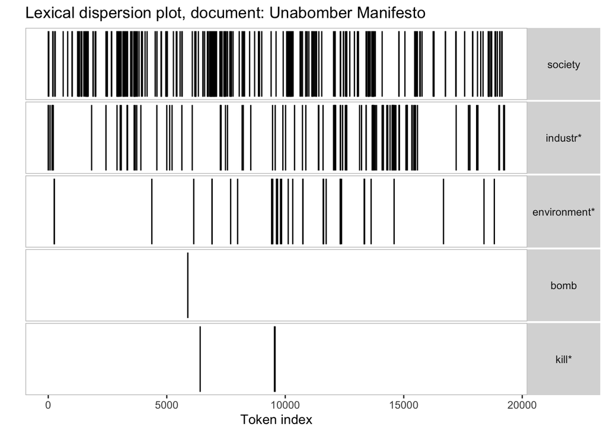

```r
library(quanteda.textplots)
names(unabomb_corpus) <- "Unabomber Manifesto"

#uses library quanteda.textplots
textplot_xray(
    kwic(quanteda::tokens(unabomb_corpus), pattern = "society"), # We live in a society
    kwic(quanteda::tokens(unabomb_corpus), pattern = "industr*"), # Anything with industry as root
    kwic(quanteda::tokens(unabomb_corpus), pattern = "environment*"), # Touch grass
    kwic(quanteda::tokens(unabomb_corpus), pattern = "bomb"), # What he did, so does he talk about it
    kwic(quanteda::tokens(unabomb_corpus), pattern = "kill*"), # What he did, so does he talk about it
    kwic(quanteda::tokens(unabomb_corpus), pattern = "mail*"), # How he sent weapons, does he talk about it
    scale = "absolute"
)
```

Notice I put an `*` after some of the word roots, like industrial or industry. This captures all versions of the word. He talks a lot about society and industry, which he was concerned about. I also have heard he’s an eco-terrorist of sorts, given that he lived in a cabin in rural Montana, and environment and its variants are fairly well distributed throughout the text, not as much as society or industry though. He also does mention “bomb” and “kill”, though rarely. He never mentions “mail,” which was his modus operandi. This suggests that the manifesto is more concerned with explaining his take on society and its systems in this manifesto, rather than detailing his crimes.

# Wordcloud

Now, I’m going to make a word cloud of the top 50 words out of the cleaned data, with larger words indicating that the word more often appears in the text.

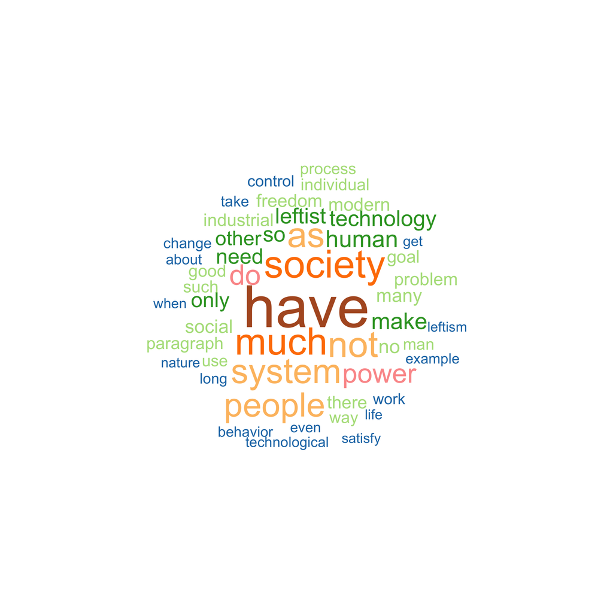

```r
library(RColorBrewer)
quanteda.textplots::textplot_wordcloud(post_dfm, random_order = FALSE, rotation = 0,
                                       color = brewer.pal(12, "Paired"), max_words = 50) #word cloud or another way
```

“Have” is the top word, which makes sense given the lemmatization of the cleaned data. Prominent nouns are “system”, “society”, “people”, “power”, and “technology,” again, checking out for this document being his diatribe on present systems.

# Top 20 document feature matrix (DFM)

Now, let’s see how many times the top 20 words actually appeared in the text.

```r
post_dfm1 <- dfm(post_tokens, dfm_stem = TRUE)
topfeatures(post_dfm1, 20)
```

```
##       have    society       much        not         as     system     people
##        437        271        262        247        243        236        226
##         do      power      human       make technology    leftist         so
##        182        170        141        134        127        125        123
##       need       only      other         no     social       many
##        121        118        110        104         98         98
```

The most used word after “have” is “society”, as well as “system”, “people”, “power”, “human”, and “technology”. Again, this is aligned with this document being a manifesto about society’s systems and its negative impacts on people’s well-being.